# Part II - Prosper Loan Dataset

## Investigation Overview

> The goal is to assess the dataset for insights on the Prosper loan scheme. I would like to see what factors are likely to determine the sucess or failure of a loan application, the social status of those in need of loans, what are the loan requirements/conditions (for example borrower rates, collateral comditions, minimum salary range, bank credit status etc.)

## Dataset Overview

> The dataset has 113,937 rows and 81 columns

```python
# import all packages and set plots to be embedded inline
import numpy as np
import pandas as pd
import matplotlib.pyplot as plt
import seaborn as sns
import os
import re
import time

%matplotlib inline

# suppress warnings from final output
import warnings
warnings.simplefilter("ignore")
```

```python
# load in the dataset into a pandas dataframe
path = r'C:\Users\Admin\Downloads\Stat Zone\jupyternotebookfiles\udacity-alx\quiz solutions\data-visualization\Prosper Loan dataset\dataset'
folder_dir = os.listdir(path)
r = re.compile(".*\.csv")
csv_file = list(filter(r.match, folder_dir))
print(csv_file)
```

```
['prosperLoanData.csv']
```

```python
filename = path + '\\' + csv_file[0]
start_time = time.time()
loan_df = pd.read_csv(filename)
end_time = time.time()
load_time = end_time - start_time
print('load time is ' + str(load_time))
```

```
load time is 4.13076376914978
```

## Loan Application

### Nature of Applicants

> Majority of the applicants aren't neccessarily collar-job officers. Students are among those who get the least loan approvals and I'd argue it's because they likely make no income for a refund. With all the categories and their low count, I'd say the major part of the "Others" are likely to be business oriented personnels/bodies.

> Applicants prefer medium to long term loan schemes and the commonest loan term is 36 Months

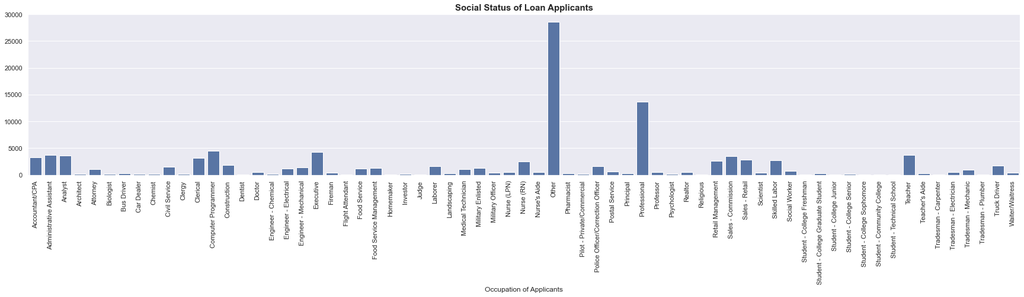

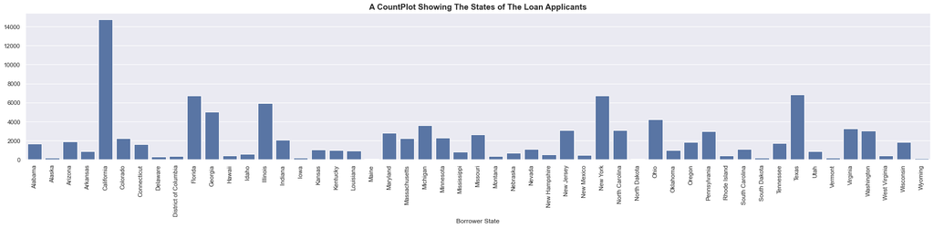

## Loan Conditions & Applicant Status

### Collateral

> Well there are almost as many Non Home Owners are there are Home Owners. So, the idea of a collateral is quickly downtrodden. I presume it wont be a strong criteria.

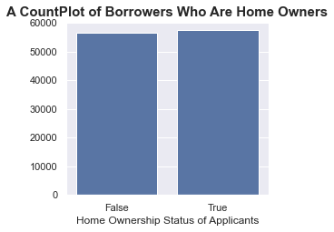

### Interest

> The Borrower rate is mostly spread between 0.1 and 0.2 (the range where most values fall).

> However, after adjusting the bin sizes, most values still seemed to distribute around the left and between .1 and .2 but the highest count changes to just over the .3 margin.

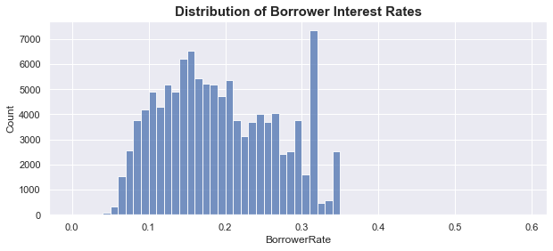

### Interest Per Loan Term

> Although, the 36 Month loans have some outliers and a fairly higher median (in terms of the Borrower Rates) than the 12 month offers.

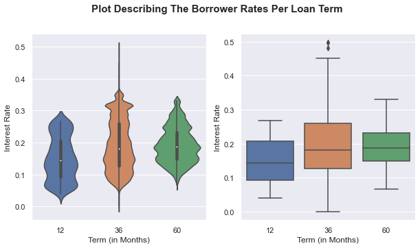

### Interest Per Employment Status

> Most beneficiaries are employed but less than half have full time employments and even way lesser are self-employed.

> This could likely correspond with my assumption of business oriented personnels because, if someone works a job part time, they likely need funds for their side-hustles/other business to look after families and mortgages and all.

> Plus, having a means of employment is a strong criteria for obtaining loans as one would likely assume due to the need for a refund with interest

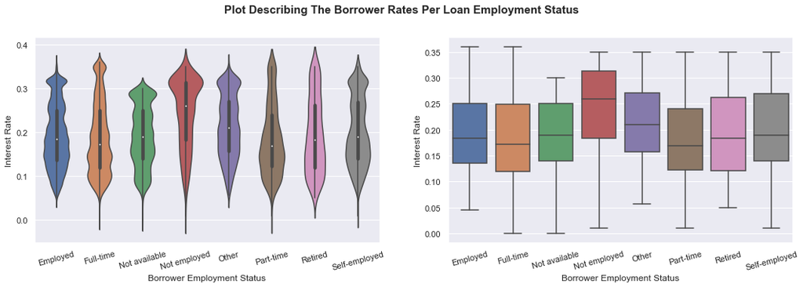

### Interest Per Income Range

> The common/median salary range happen to appear on the rightmost parts where the highest rates are with the low earners of the median range having the most people.

> The higher percentage of those with the lower rates are often found with high income earners.

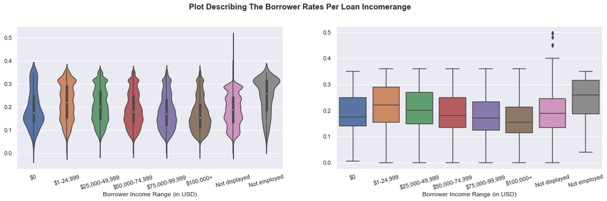

## Loan Repayment

### Quickest Refunds?

> Though the columns analysed is missing a time information of refund dates of some sort but we can look at the completed loans and their interst rates and tell what's common

> Those who are also in line of making final payment also have their median rates not so far from the .2 mark

> There are definitely other things but can peg it at just the interest rates for now

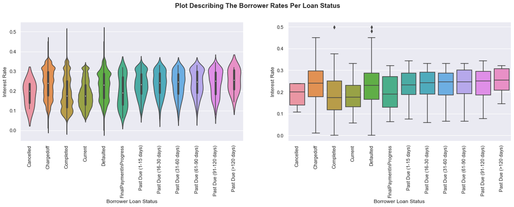

### Best Moving Loan Schemes?

> 36 Month loan schemes is looking like the 'moving' business for the Propser Loan company

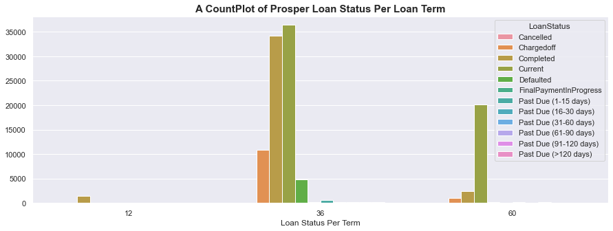

```python
# Use this command if you are running this file in local
!jupyter nbconvert Part_II_slide_deck_template.ipynb --to slides --post serve --no-input --no-prompt
```

> In the classroom workspace, the generated HTML slideshow will be placed in the home folder.

### Submission

   ```
   zip -r my_project.zip .
   ```